# Homework 2

Rolando Santos - https://github.com/rsantos2032/DSCI401

2023-09-07

```r
library(mdsr)
library(tidyverse)
library(Lahman)
library(mdsr)
```

### Question 1: Using the Teams data frame in the Lahman package:

#### a. Create a data frame that is a subset of the Teams data frame that contains only the years from 2000 through 2009 and the variables yearID, W, and L.

```r
teams_subset <- Teams %>% select(yearID, W, L) %>% filter(yearID >= 2000 & yearID <= 2009)
head(teams_subset)
```

```
##   yearID  W  L
## 1   2000 82 80
## 2   2000 85 77
## 3   2000 95 67
## 4   2000 74 88
## 5   2000 85 77
## 6   2000 95 67
```

#### b. How many years did the Chicago Cubs (teamID is “CHN”) hit at least 200 HRs in a season and what was the median number of wins in those seasons.

```r
summarized_win <- Teams %>% filter(teamID == "CHN") %>% group_by(yearID) %>% summarize(sum_hr = sum(HR)) %>% filter(sum_hr >= 200)
summarized_win
```

```
## # A tibble: 7 × 2
##   yearID sum_hr
##    <int>  <int>
## 1   1987    209
## 2   1998    212
## 3   2002    200
## 4   2004    235
## 5   2017    223
## 6   2019    256
## 7   2021    210
```

```r
median(summarized_win$sum_hr)
```

```
## [1] 212
```

#### c. Create a factor called election that divides the yearID into 4-year blocks that correspond to U.S. presidential terms. The first presidential term started in 1788. They each last 4 years and are still on the schedule set in 1788. During which term were the most home runs been hit?

```r
Teams %>% mutate(election = factor(((Teams$yearID - Teams$yearID %% 4) - 1788)/4 + 1)) %>% group_by(election) %>% summarise(election_HR = sum(HR)) %>% filter(election_HR == max(election_HR))
```

```
## # A tibble: 1 × 2
##   election election_HR
##   <fct>          <int>
## 1 58             24076
```

The most home runs by term was achieved in the 58 presidential election term (2016).

#### d. Make a line plot of total home runs per season and stratify by league. Remove observations where league is missing.

##### As a single plot

[figure not shown]

```r
library(ggplot2)

#For some reason NA is seen as a string so !is.na() was not working
Teams %>% filter(lgID != "NA") %>%
  ggplot(
  aes(x = yearID, y = HR, color = lgID)
) +
  geom_line() +
  xlab("Year") +
  ylab("Home Runs") +
  geom_smooth(se = FALSE)
```

##### As a faceted plot

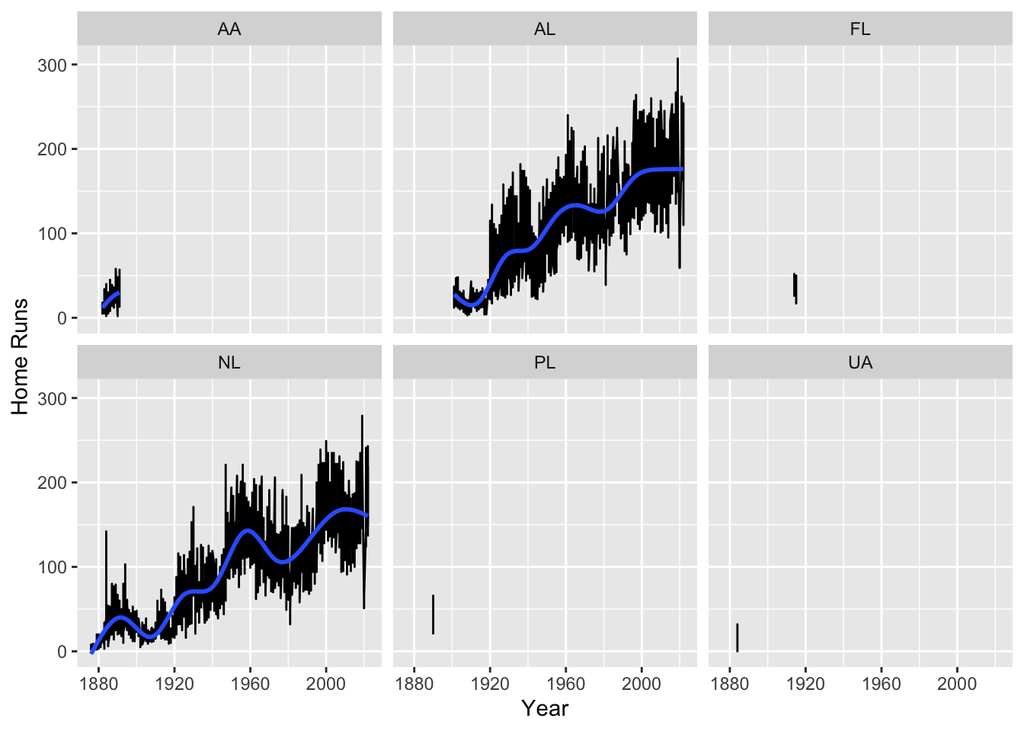

```r
Teams %>% filter(lgID != "NA") %>%
  ggplot(
  aes(x = yearID, y = HR)
) +
  geom_line() +
  xlab("Year") +
  ylab("Home Runs") +
  geom_smooth(se = FALSE) +
  facet_wrap(~lgID)
```

#### e. Create an indicator variable called “winning record” which is defined as TRUE if the number of wins is greater than the number of losses and FALSE otherwise. Plot a scatter plot of Runs (R) vs Runs against (RA) with the color of each point showing whether that team had a winning record or not.

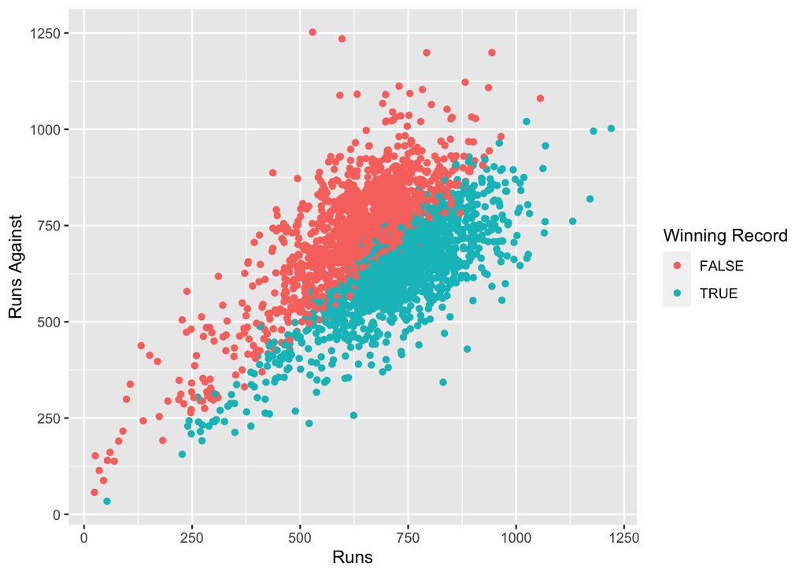

```r
Teams <-Teams %>% mutate(winning_record = W > L)

Teams %>% ggplot(
  aes(x = R, y = RA, color = winning_record)
) +
  geom_point() +
  xlab("Runs") +
  ylab("Runs Against") +
  labs(color = "Winning Record")
```

### Question 2: The Violations data set in the mdsr package contains information regarding the outcome of health inspections of restaurants in New York City.

#### a. What proportion of inspections in each boro were given a grade of A? (Missing values should be counted as not an A grade.)

```r
#Using %in% due to grade == A returning NA whenever grade is NA
Violations %>% mutate(a_grade = ifelse(grade %in% "A", TRUE, FALSE)) %>% group_by(boro) %>% summarize(prop = mean(a_grade, na.rm = TRUE))
```

```
## # A tibble: 6 × 2
##   boro           prop
##   <chr>         <dbl>
## 1 BRONX         0.352
## 2 BROOKLYN      0.330
## 3 MANHATTAN     0.342
## 4 Missing       0.452
## 5 QUEENS        0.329
## 6 STATEN ISLAND 0.362
```

#### b. Find the top ten dba’s with the most number of inspections. Then compute the average score for each of these dba’s andsort by mean score. Which of these top 10 had the lowest average inspection score?

```r
most_violations = (Violations %>% group_by(dba) %>% summarize(num_violations = n()) %>% arrange(-num_violations))[1:10, ]
most_violations
```

```
## # A tibble: 10 × 2
##    dba                                   num_violations
##    <chr>                                          <int>
##  1 SUBWAY                                          5005
##  2 DUNKIN' DONUTS                                  4967
##  3 MCDONALD'S                                      4078
##  4 STARBUCKS                                       2442
##  5 DUNKIN' DONUTS, BASKIN ROBBINS                  1951
##  6 CROWN FRIED CHICKEN                             1724
##  7 DOMINO'S                                        1492
##  8 BURGER KING                                     1466
##  9 KENNEDY FRIED CHICKEN                           1435
## 10 GOLDEN KRUST CARIBBEAN BAKERY & GRILL           1134
```

```r
Violations %>% filter(dba %in% most_violations$dba) %>% group_by(dba) %>% summarize(avg = mean(score, na.rm = TRUE)) %>% arrange(avg)
```

```
## # A tibble: 10 × 2
##    dba                                     avg
##    <chr>                                 <dbl>
##  1 STARBUCKS                              11.7
##  2 DUNKIN' DONUTS                         13.6
##  3 DUNKIN' DONUTS, BASKIN ROBBINS         14.5
##  4 SUBWAY                                 14.8
##  5 MCDONALD'S                             17.0
##  6 BURGER KING                            17.3
##  7 KENNEDY FRIED CHICKEN                  18.0
##  8 GOLDEN KRUST CARIBBEAN BAKERY & GRILL  18.3
##  9 CROWN FRIED CHICKEN                    18.6
## 10 DOMINO'S                               18.6
```

From the results it appears that STARBUCKS had the lowest mean average with a mean score of 11.66435.

#### c. Use these data to calculate the median violation score by zip code for zip codes in Manhattan with 50 or more inspections. What pattern do you see between the number of inspections and the median score?

```r
inspections_manhattan = Violations %>% filter(boro == "MANHATTAN") %>% group_by(zipcode) %>% summarize(num_inspections = n(), med = median(score, na.rm = TRUE)) %>% filter(num_inspections >= 50)
inspections_manhattan
```

```
## # A tibble: 51 × 3
##    zipcode num_inspections   med
##      <int>           <int> <dbl>
##  1   10001            8420    15
##  2   10002            9113    18
##  3   10003           13556    17
##  4   10004            2304    14
##  5   10005            1209    17
##  6   10006             977    17
##  7   10007            2356    16
##  8   10009            6131    17
##  9   10010            4658    17
## 10   10011            8790    17
## # ℹ 41 more rows
```

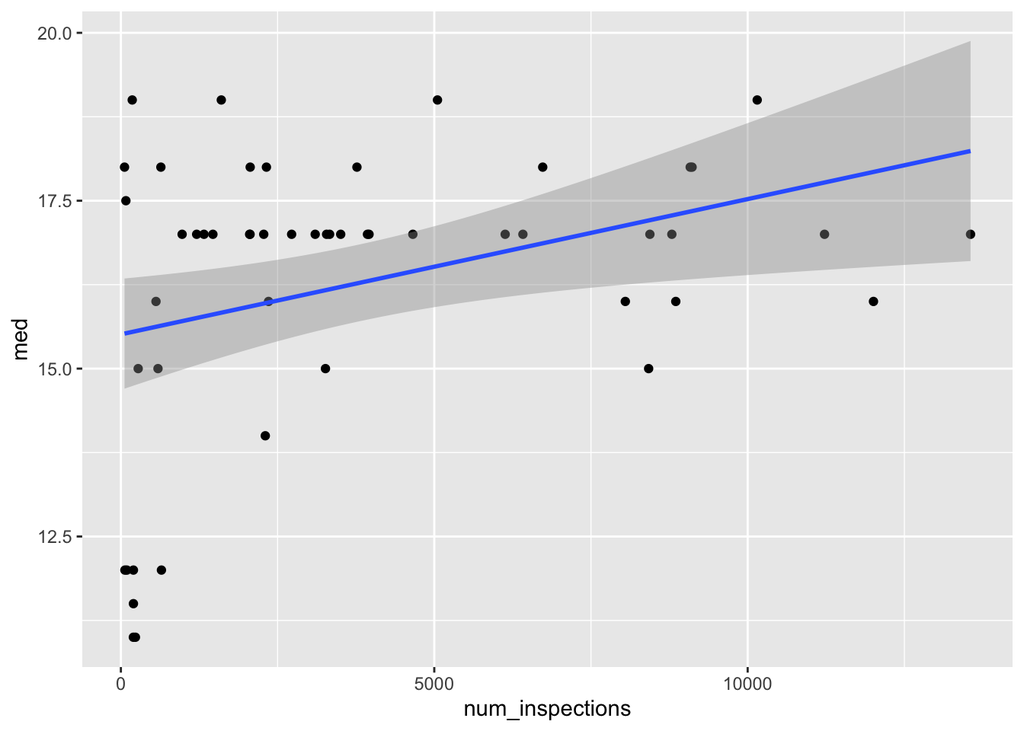

```r
inspections_manhattan %>% ggplot(
  aes(x = num_inspections, y = med)
) +
  geom_point() +
  geom_smooth(method = "lm")
```

From the graph we can see that most zip codes with a low median score have less occurences of inspections compared to median score of ~16 and above.